# icpsr2ftldb: Importing the ICPSR 33501 source into a full text long format database

Berkeley D-Lab Computational Text Analysis Working Group

This notebook teaches you about data importing using the example of the *Congressional Record for 104th-110th Congresses* provided by the [ICPSR 33501](http://www.icpsr.umich.edu/icpsrweb/ICPSR/studies/33501) repository. The objective is to import data from the original source and convert it into a full text research database that can be easily queried to answer different questions and apply different methods.

“Garbage in garbage out” implies that even very well-behaved sources will likely require plenty of preparation before they can be used for analysis. Building a library of functions helps you keep the “original” data intact in the form that it was downloaded or acquired and lets you reproduce the cleaning process. This is especially important when working with collaborators or when trying to share your work, but even if you are working along it is a good idea to leave a paper trail in the form of a function or set of functions designed to process the original into a useful database.

# GIGO: garbage in gold out

When we say “source” we often mean where our data came from, and whatever the format is you’ll likely have to come back to it again and again. Let’s call this a datadump, because it’s messy and we need to clean it up before we can use it for research.

A software source, similarly, is a place where you keep pieces of code that you use over and over again. If we think of our pipeline or workflow, we can think of the software source as the pipe that we’ll use to turn our datadump into a database.

A database, unlike a datadump, is conveniently formatted, structured, and cleaned so that it is a breeze to work with it for research purposes. A database should be easily queriable, letting the researcher pull arbitrary samples for a variety of analytical goals. This is our gold standard and what we’re shooting for in this vignette: garbage in, gold out, or *gigo*!

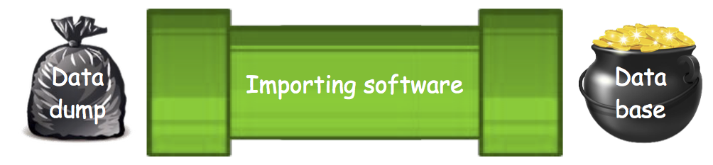

*Figure 313. GIGO!*

# Source

## Datadumps

Datadumps each tend to have their own quirks, which means that making a project out of the importing step can never really be avoided. It would be nice if text analysis folks adopted one universal standard, but we haven’t yet!

Let’s navigate to the [ICPSR website](http://www.icpsr.umich.edu/icpsrweb/ICPSR/studies/33501) we mentioned and aqcuire our datadump. This repository has a lot of different downloads to choose from; we’re looking for three things:

1. **DS15**: The full text transcripts of Congressional floor speeches (actually we will see that “speech acts” is a better description).
2. **DS19**: Metadata about the congresspeople and other speakers giving the speeches.
3. **DS20**: Metadata about the source of the speeches, a document called the Congressional Record.

If you’ve cloned this repo, you’ll have an empty folder called “datadump”. You’ll need about 0.5 GB (500 MB) of space for this step. Save the zip archives there, and it won’t matter what you call them, though note that they all have the same name so check that you haven’t overwritten anything.

The DS15 file is about a decade of speeches and weighs in at about 430 MB compressed, and almost triple that uncompressed. Unfortunately there is no way to get to the subsamples without downloading the whole thing at least once. If you’d like to see the digital original sources, use take a look at any of the “Original” download options containing speeches in xml format.

It might make sense to unzip the archive you downloaded from ICPSR to see what’s inside, but from the standpoint of reproducibility, it would be best if could build our function to accept a file path to the original zip archive that we got from the ICPSR website. This will make it simple to start from a fresh download without any intermediate steps.

[figure not shown]

*Figure 314. Silly Data Hygiene!*

We maintain that working with the original data file, no matter how silly it may be, is a quality criterion for reproducible research. We’ll see what we can do to try to be computationally efficient despite the double-zip hurdle.

## Importing software

Now that we have our datadump in hand, let’s work with some custom software to make it useable. In general think about a software source as a library of functions, like an R package, but one we can write ourselves if we need to. Check About R Functions for a quick intro to writing your own functions.

We’ve prepared some functions to import these data, so let’s load that “library”, which is now just a script file with a bunch of function definitions in it called `1source/icpsr-import-src.R`. We can load them using the `source()` function.

```r
source('1source/icpsr-import-src.R')
lsf.str() # this lists new (not in a library) functions and their arguments
```

```
p1.icpsr2RData : function (src.dir, out.dir, verbose = F, return = F)
p2.icpsr2ftldb : function ()
p3.ftldb2bow : function (src.dir, save.dir = src.dir)
p4.bow2stm : function (bow, id = "speechID")
u.txt2ppt : function (x, split = "\\s+")
```

We’ve coded these functions with “p” for pipeline followed by a number indicating the order of the pipelines through which our data will flow. Functions with a “u” are utilities that we may use for different reasons and at different steps.

# Pipe

## P1: Redumping ICPSR

### …as .RData

Let’s take a look at the first pipeline, the `p1.icpsr2RData` function. If we just call the object name without parantheses, it will print the function definition as it was read from disk. We won’t do that because we completely tortured the code with comments explaining what every line does. Bad style but a good idea for remembering what we did or explaining it to others. It’s too much to print here, but take a look at the source file, especially with syntax highlighting, if you want a detailed explanation. Here’s a cleaner look using the `head` function.

```r
head(p1.icpsr2RData,9) # prints the top lines of the function contents all nice and tidy as R parsed it (rather than how we wrote it)
```

```
1 function (src.dir, out.dir, verbose = F, return = F)
2 {
3     require(data.table)
4     require(bit64)
5     require(magrittr)
6     strppath <- function(x) sub(paste0("^.+", .Platform$file.sep),
7         "", x)
8     t0 <- proc.time()
9     for (z in dir(src.dir, full.names = T)) {
```

```r
tail(p1.icpsr2RData,9) # the bottom lines
```

```
49         dump[[n]] <- dt
50         for (i in setdiff(names(dump), n)) if (length(i)) {
51             load(paste(out.dir, i, sep = .Platform$file.sep))
52             dump[[i]] <- dt
53             rm(dt)
54         }
55         return(dump)
56     }
57 }
```

57 lines of code isn’t huge but it isn’t small either. This function is complicated mostly because of the zipping problem. It still makes several duplications of the data so it’s not an ideal solution, but it works, and the function can always be modified in the future if we learn a better way.

### Subsampling

Now that we have an R object it is easier to take subsamples. We still aren’t quite at a research-ready database, but if you need to serve something that is basically the same as the source, it is easy to do using the `data.table` package.

```r
load(dir('2pipe',pattern='0015.+RData',full.names = T)) # the dir() function makes it easy to use regular expressions to find the file you're looking for
tables() # note that our object is called dt for short
```

```
     NAME      NROW NCOL  MB COLS            KEY
[1,] dt   1,212,589    2 818 speechID,speech
Total: 818MB
```

When data are this large, some R conventions don’t perform well, especially basic indexing and subsetting. That’s where `data.table` is a big help. `data.table` basically makes good use of sorting to find things quickly.

```r
setkey(dt,speechID) # sort or "key" by speechID. Here the speechIDs are already cronologically coded, so sorting will put them in logical order as well. If your data are in a logical order that will be garbled by sorting, be sure to save the original sort order as a new variable so you can recover it.
set.seed(12345) # this will give us the same sample every time
sdt<-dt[sample(dt$speechID,size=1000)] # subset using data.table
setkey(sdt,speechID) # key again
tables() # now how big is it?
```

```
     NAME      NROW NCOL  MB COLS            KEY
[1,] dt   1,212,589    2 818 speechID,speech speechID
[2,] sdt      1,000    2   2 speechID,speech speechID
Total: 820MB
```

### …as .“C”SV

```r
rm(dt) # let's free up some memory by removing the big table from memory
write.table(sdt,file = '2pipe/33501-0015-Data-1ksubsamp.txt',quote = F,sep = '|',row.names = F) # saving to "|"" delimited text file
tdt<-fread(input = '2pipe/33501-0015-Data-1ksubsamp.txt',colClasses = c(speechID='character')) # Let's test that we can read it in exactly as we wrote it.
setkey(tdt,speechID)
if(identical(sdt,tdt)) cat("Yay they're the same, we did it!")
```

```
Yay they're the same, we did it!
```

```r
rm(tdt)
```

Now let’s also subset our two sources of metadata.

```r
load(dir('2pipe',pattern='20.+RData',full.names = T)) # Search for data set 20 from ICPSR and load it. This is information about the document, including speaker id.
tables() # as expected it is as long as our speech table, though a lot smaller.
```

```
     NAME      NROW NCOL  MB
[1,] dt   1,212,589   10 154
[2,] sdt      1,000    2   2
     COLS                                                                             KEY
[1,] speechID,date,num_order_within_file,speakerID,file,line_start,line_end,page,char
[2,] speechID,speech                                                                  speechID
Total: 156MB
```

```r
setkey(dt,speechID)
smdt<-dt[sdt$speechID]
tables() #our small meta data table
```

```
     NAME      NROW NCOL  MB
[1,] dt   1,212,589   10 154
[2,] sdt      1,000    2   2
[3,] smdt     1,000   10   1
     COLS                                                                             KEY
[1,] speechID,date,num_order_within_file,speakerID,file,line_start,line_end,page,char speechID
[2,] speechID,speech                                                                  speechID
[3,] speechID,date,num_order_within_file,speakerID,file,line_start,line_end,page,char speechID
Total: 157MB
```

```r
load(dir('2pipe',pattern='19.+RData',full.names = T)) # Search for and load data set 19 from ICPSR. This is the much shorter speaker table. Note that each of these objects is called "dt" so they will write over each other. That's what we want since we don't need the long document description file any more.
tables() # there are 3,819 different speakers listed here
```

```
     NAME  NROW NCOL MB
[1,] dt   3,819    6  1
[2,] sdt  1,000    2  2
[3,] smdt 1,000   10  1
     COLS                                                                             KEY
[1,] id,state,name,chamber,district,party
[2,] speechID,speech                                                                  speechID
[3,] speechID,date,num_order_within_file,speakerID,file,line_start,line_end,page,char speechID
Total: 4MB
```

```r
setkey(dt,id) # why they changed the convention and called it "id" instead of "speakerID" we can only guess.
ssdt<-dt[unique(smdt$speakerID)] # since speakers may have spoken multiple times, let's search for only unique speaker ids.
rm(dt)
tables() # our sample of 1000 speeches represents 592 of the speakers we have information about
```

```
     NAME  NROW NCOL MB
[1,] sdt  1,000    2  2
[2,] smdt 1,000   10  1
[3,] ssdt   592    6  1
     COLS                                                                             KEY
[1,] speechID,speech                                                                  speechID
[2,] speechID,date,num_order_within_file,speakerID,file,line_start,line_end,page,char speechID
[3,] id,state,name,chamber,district,party
Total: 4MB
```

So those are the three different subsets of our data. Storing them separately is the most space efficient way, but not necessarily the most convenient. Let’s merge them into one big table by matching on the two diffrent keys, `speechID` and `speakerID`.

```r
smsdt<-merge(x=smdt,y=ssdt,by.x='speakerID',by.y='id') # merge by the same key, which to our chagrin was given two different names
tables()
```

```
     NAME   NROW NCOL MB
[1,] sdt   1,000    2  2
[2,] smdt  1,000   10  1
[3,] smsdt 1,000   15  1
[4,] ssdt    592    6  1
     COLS                                                                             KEY
[1,] speechID,speech                                                                  speechID
[2,] speechID,date,num_order_within_file,speakerID,file,line_start,line_end,page,char speechID
[3,] speakerID,speechID,date,num_order_within_file,file,line_start,line_end,page,char speakerID
[4,] id,state,name,chamber,district,party
Total: 5MB
```

```r
setkey(smsdt,speechID)
allsdt<-merge(x=sdt,y=smsdt) # will merge on the mutual key if they have the same name
setkey(allsdt,speechID)
tables()
```

```
     NAME    NROW NCOL MB
[1,] allsdt 1,000   16  2
[2,] sdt    1,000    2  2
[3,] smdt   1,000   10  1
[4,] smsdt  1,000   15  1
[5,] ssdt     592    6  1
     COLS                                                                             KEY
[1,] speechID,speech,speakerID,date,num_order_within_file,file,line_start,line_end,pa speechID
[2,] speechID,speech                                                                  speechID
[3,] speechID,date,num_order_within_file,speakerID,file,line_start,line_end,page,char speechID
[4,] speakerID,speechID,date,num_order_within_file,file,line_start,line_end,page,char speechID
[5,] id,state,name,chamber,district,party
Total: 7MB
```

```r
write.table(smsdt,file = '2pipe/33501-0015-Data-1ksubsamp.meta.only.txt',quote = F,sep = '|',row.names = F) # saving to "|"" delimited text file
write.table(allsdt,file = '2pipe/33501-0015-Data-1ksubsamp.w.meta.txt',quote = F,sep = '|',row.names = F) # saving to "|"" delimited text file
```

### Sanity Check!

Our metadata have two values, `char count` and `word count`. These two values together are almost a finger print for the document. Let’s test to see if our full text field adds up the way it is supposed to by adding our own versions of character and word count and a `test` column to our table.

```r
library(qdap) # for the word_count aka wc function
invisible(allsdt[,`:=`(
    char_count=nchar(speech) #easy, count the number of characters
    ,word_count=sapply(gregexpr('[^ ]+',gsub('[^0-9A-Za-z ]+','',allsdt$speech)),length) # hacky? count the number of contiguous non-whitespace #wc(speech)
)])
invisible(allsdt[,`:=`(
    ctest=`char count`==char_count
    ,wtest=`word count`==word_count
)])
ftable(allsdt[,list(ctest,wtest)])
```

```
      wtest FALSE TRUE
ctest
FALSE         435    9
TRUE           49  507
```

Holy smokes! That isn’t good. It looks like nearly half of our database doesn’t match up! Let’s take a look at three cases for each test category. Here keying the `data.table` by our two test columns will be helpful.

```r
setkey(allsdt,ctest,wtest)
#Looking good
gg<-allsdt[list(T,T),list(speechID,`char count`,char_count,`word count`,word_count,speech,file,line_start,line_end)][1:3]
#Character good word bad
gb<-allsdt[list(T,F),list(speechID,`char count`,char_count,`word count`,word_count,speech,file,line_start,line_end)][1:3]
#Character bad word good
bg<-allsdt[list(F,T),list(speechID,`char count`,char_count,`word count`,word_count,speech,file,line_start,line_end)][1:3]
#Both bad
bb<-allsdt[list(F,F),list(speechID,`char count`,char_count,`word count`,word_count,speech,file,line_start,line_end)][1:3]
#let's look at the very bad category
bb
```

| speechID | char count | char_count | word count | word_count | speech | file | line_start | line_end |
| --- | --- | --- | --- | --- | --- | --- | --- | --- |
| 10419950001379 | 60 | 22 | 13 | 4 | In this particular CR? | Hcr19ja95-62 1.txt | 169 | 170 |
| 10419950005157 | 2523 | 143 | 444 | 25 | Mr. Speaker, I ask unanimous consent that all Members may have 5 legislative days within which to revise and extend their remarks on H.R. 2853. | Hcr02fe95-56 1.txt | 685 | 727 |
| 10419950005955 | 39 | 5359 | 7 | 865 | Mr. Speaker, I thank the gentleman for yielding time to me. Mr. Speaker, while I support our committee's efforts to obtain all of the relevant information regarding the Travel Office firings, I do not… | Hcr03fe95-77 1.txt | 3882 | 3882 |

Some of these cases seem definitely wrong, and other seem like the variations could be due to different methods of counting. Let’s plot the difference between our counts and the original authors and see what clusters.

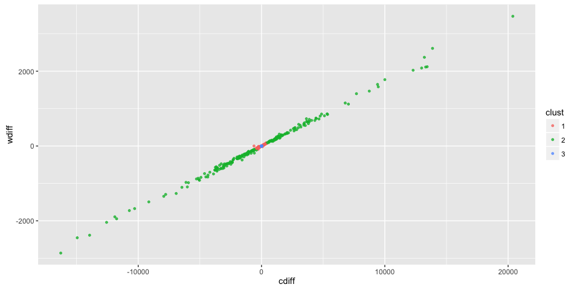

Yup it still looks pretty bad! There are a lot of points far away from zero, so clearly something is up with our ability to match metadata. Did we make an error, or was it in the original data? Thankfully the ICPSR database includes the original documents that were parse, and these are what the speech description file refers to. These files are saved in our `1source/original` folder. Let’s view the last set of cases above that failed both of our tests.